# Practice Activity 9.1: Classification Models

Author

Jake Cross

At this link, you will find a dataset containing information about heart disease patients: https://www.dropbox.com/scl/fi/0vrpdnq5asmeulc4gd50y/ha_1.csv?rlkey=ciisalceotl77ffqhqe3kujzv&dl=1

A description of the original dataset can be found here: https://archive.ics.uci.edu/dataset/45/heart+disease (However, this dataset has been cleaned and reduced, and the people have been given fictious names.)

## 1. Logistic Regression

Fit a Logistic Regression using only `age` and `chol` (cholesterol) as predictors.

For a 55 year old, how high would their cholesterol need to be for the doctors to predict heart disease is present?

How high for the doctors to estimate a 90% chance that heart disease is present?

```python
import pandas as pd
import numpy as np

url = "https://www.dropbox.com/scl/fi/0vrpdnq5asmeulc4gd50y/ha_1.csv?rlkey=ciisalceotl77ffqhqe3kujzv&dl=1"

df = pd.read_csv(url)

display(df.head())

print("Shape:", df.shape)
print("Columns:", df.columns.tolist())

df.info()

print("Missing Values:")
display(df.isna().sum())
```

|  | Name | age | sex | cp | trtbps | chol | restecg | thalach | diagnosis |
| --- | --- | --- | --- | --- | --- | --- | --- | --- | --- |
| 0 | Magnolia Cassin | 60 | 1 | 1 | 117 | 230 | 1 | 160 | No Disease |
| 1 | Dr. Cathern Heathcote | 60 | 0 | 3 | 102 | 318 | 1 | 160 | Disease |
| 2 | Miles Wolf | 62 | 0 | 3 | 130 | 263 | 1 | 97 | No Disease |
| 3 | Mikaila Block | 43 | 1 | 1 | 115 | 303 | 1 | 181 | Disease |
| 4 | Mrs. Jacquline Marquardt | 66 | 1 | 1 | 120 | 302 | 0 | 151 | Disease |

```
Shape: (204, 9)
Columns: ['Name', 'age', 'sex', 'cp', 'trtbps', 'chol', 'restecg', 'thalach', 'diagnosis']
<class 'pandas.core.frame.DataFrame'>
RangeIndex: 204 entries, 0 to 203
Data columns (total 9 columns):
 #   Column     Non-Null Count  Dtype
---  ------     --------------  -----
 0   Name       204 non-null    object
 1   age        204 non-null    int64
 2   sex        204 non-null    int64
 3   cp         204 non-null    int64
 4   trtbps     204 non-null    int64
 5   chol       204 non-null    int64
 6   restecg    204 non-null    int64
 7   thalach    204 non-null    int64
 8   diagnosis  204 non-null    object
dtypes: int64(7), object(2)
memory usage: 14.5+ KB
Missing Values:
```

```
Name         0
age          0
sex          0
cp           0
trtbps       0
chol         0
restecg      0
thalach      0
diagnosis    0
dtype: int64
```

```python
print("Diagnosis Categories:")
display(df["diagnosis"].value_counts())

print("Age and Cholesterol Summary:")
display(df[["age", "chol"]].describe())

assert df[["age", "chol", "diagnosis"]].notna().all().all()
```

```
Diagnosis Categories:
```

```
diagnosis
Disease       115
No Disease     89
Name: count, dtype: int64
```

```
Age and Cholesterol Summary:
```

|  | age | chol |
| --- | --- | --- |
| count | 204.000000 | 204.000000 |
| mean | 53.813725 | 248.377451 |
| std | 9.354781 | 53.176624 |
| min | 29.000000 | 126.000000 |
| 25% | 46.000000 | 212.750000 |
| 50% | 54.000000 | 241.000000 |
| 75% | 61.000000 | 276.250000 |
| max | 77.000000 | 564.000000 |

```python
from sklearn.linear_model import LogisticRegression
import numpy as np

X = df[["age", "chol"]]
y = df["diagnosis"]

logistic_model = LogisticRegression(max_iter=1000)
logistic_model.fit(X, y)

print("Classes:", logistic_model.classes_)
print("Intercept:", logistic_model.intercept_[0])
print("Coefficients:", logistic_model.coef_[0])

negative_labels = {"no", "absent", "negative", "healthy", "false", "0"}

present_label = next(
    label for label in logistic_model.classes_
    if str(label).strip().lower() not in negative_labels
    and not str(label).strip().lower().startswith(("no ", "not "))
    and "absent" not in str(label).lower()
)

sign = 1 if logistic_model.classes_[1] == present_label else -1

b0 = sign * logistic_model.intercept_[0]
b_age = sign * logistic_model.coef_[0][0]
b_chol = sign * logistic_model.coef_[0][1]

chol_50 = -(b0 + b_age * 55) / b_chol
chol_90 = (np.log(0.9 / 0.1) - b0 - b_age * 55) / b_chol

print("Cholesterol at 50% probability:", round(chol_50, 2))
print("Cholesterol at 90% probability:", round(chol_90, 2))
```

```
Classes: ['Disease' 'No Disease']
Intercept: -3.2401122588588485
Coefficients: [0.04686331 0.00180124]
Cholesterol at 50% probability: 367.87
Cholesterol at 90% probability: -851.97
```

## 2. Linear Discriminant Analysis

Fit an LDA model using only `age` and `chol` (cholesterol) as predictors.

For a 55 year old, how high would their cholesterol need to be for the doctors to predict heart disease is present?

```python
from sklearn.discriminant_analysis import LinearDiscriminantAnalysis

lda_model = LinearDiscriminantAnalysis()
lda_model.fit(X, y)

print("Classes:", lda_model.classes_)
print("Intercept:", lda_model.intercept_[0])
print("Coefficients:", lda_model.coef_[0])

lda_sign = 1 if lda_model.classes_[1] == "Disease" else -1

lda_b0 = lda_sign * lda_model.intercept_[0]
lda_b_age = lda_sign * lda_model.coef_[0][0]
lda_b_chol = lda_sign * lda_model.coef_[0][1]

lda_chol_50 = -(lda_b0 + lda_b_age * 55) / lda_b_chol

print("Cholesterol at 50% probability:", round(lda_chol_50, 2))
```

```
Classes: ['Disease' 'No Disease']
Intercept: -3.2196776604068775
Coefficients: [0.04655744 0.00178967]
Cholesterol at 50% probability: 368.24
```

## 3. Support Vector Classifier

Fit an SVC model using only `age` and `chol` as predictors. Don’t forget to tune the regularization parameter.

For a 55 year old, how high would their cholesterol need to be for the doctors to predict heart disease is present?

```python
from sklearn.svm import SVC
from sklearn.preprocessing import StandardScaler
from sklearn.pipeline import Pipeline
from sklearn.model_selection import GridSearchCV, StratifiedKFold

svc_pipeline = Pipeline([
    ("scaler", StandardScaler()),
    ("svc", SVC(kernel="linear"))
])

svc_grid = GridSearchCV(
    svc_pipeline,
    {"svc__C": [0.001, 0.01, 0.1, 1, 10, 100]},
    cv=StratifiedKFold(n_splits=5, shuffle=True, random_state=42),
    scoring="accuracy"
)

svc_grid.fit(X, y)

svc_model = svc_grid.best_estimator_

scaler = svc_model.named_steps["scaler"]
svc = svc_model.named_steps["svc"]

coefficients = svc.coef_[0] / scaler.scale_
intercept = svc.intercept_[0] - np.sum(
    svc.coef_[0] * scaler.mean_ / scaler.scale_
)

sign = 1 if svc.classes_[1] == "Disease" else -1

svc_chol_50 = -(intercept + coefficients[0] * 55) / coefficients[1]

print("Best C:", svc_grid.best_params_["svc__C"])
print("Cross-Validation Accuracy:", svc_grid.best_score_)
print("Classes:", svc.classes_)
print("Coefficients:", coefficients)
print("Intercept:", intercept)
print("Cholesterol Decision Boundary at Age 55:", round(svc_chol_50, 2))
```

```
Best C: 1
Cross-Validation Accuracy: 0.5932926829268294
Classes: ['Disease' 'No Disease']
Coefficients: [0.06439285 0.00366051]
Intercept: -4.686238790949016
Cholesterol Decision Boundary at Age 55: 312.7
```

## 4. Comparing Decision Boundaries

Make a scatterplot of `age` and `chol`, coloring the points by their true disease outcome. Add a line to the plot representing the **linear separator** (aka **decision boundary**) for each of the three models above.

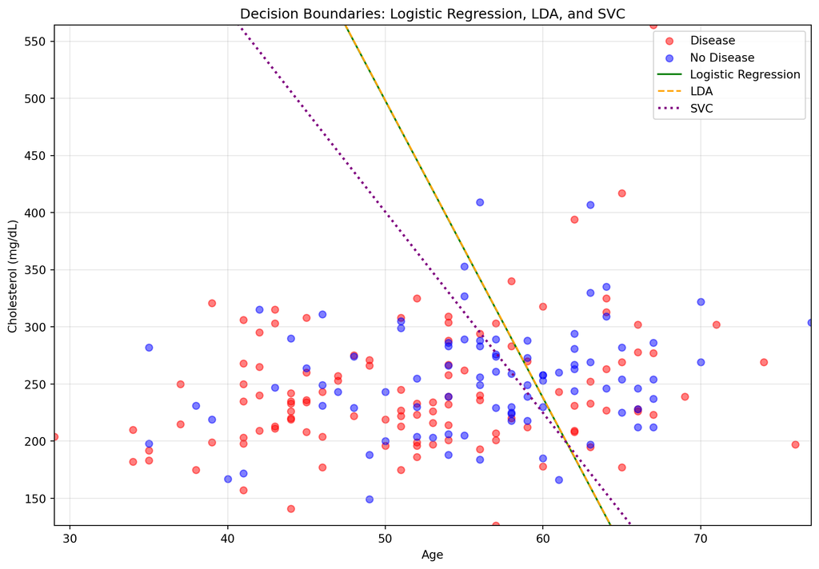

```python
import matplotlib.pyplot as plt

ages = np.linspace(df["age"].min(), df["age"].max(), 200)

logistic_boundary = -(
    logistic_model.intercept_[0] + logistic_model.coef_[0][0] * ages
) / logistic_model.coef_[0][1]

lda_boundary = -(
    lda_model.intercept_[0] + lda_model.coef_[0][0] * ages
) / lda_model.coef_[0][1]

svc_boundary = -(
    intercept + coefficients[0] * ages
) / coefficients[1]

plt.figure(figsize=(10, 7))

for diagnosis, color in [("Disease", "red"), ("No Disease", "blue")]:
    subset = df[df["diagnosis"] == diagnosis]
    plt.scatter(
        subset["age"],
        subset["chol"],
        color=color,
        alpha=0.5,
        label=diagnosis
    )

plt.plot(ages, logistic_boundary, color="green", label="Logistic Regression")
plt.plot(ages, lda_boundary, color="orange", linestyle="--", label="LDA")
plt.plot(ages, svc_boundary, color="purple", linestyle=":", linewidth=2, label="SVC")

plt.xlabel("Age")
plt.ylabel("Cholesterol (mg/dL)")
plt.title("Decision Boundaries: Logistic Regression, LDA, and SVC")
plt.xlim(df["age"].min(), df["age"].max())
plt.ylim(df["chol"].min(), df["chol"].max())
plt.legend()
plt.grid(alpha=0.3)
plt.tight_layout()
plt.show()
```